# Introduction

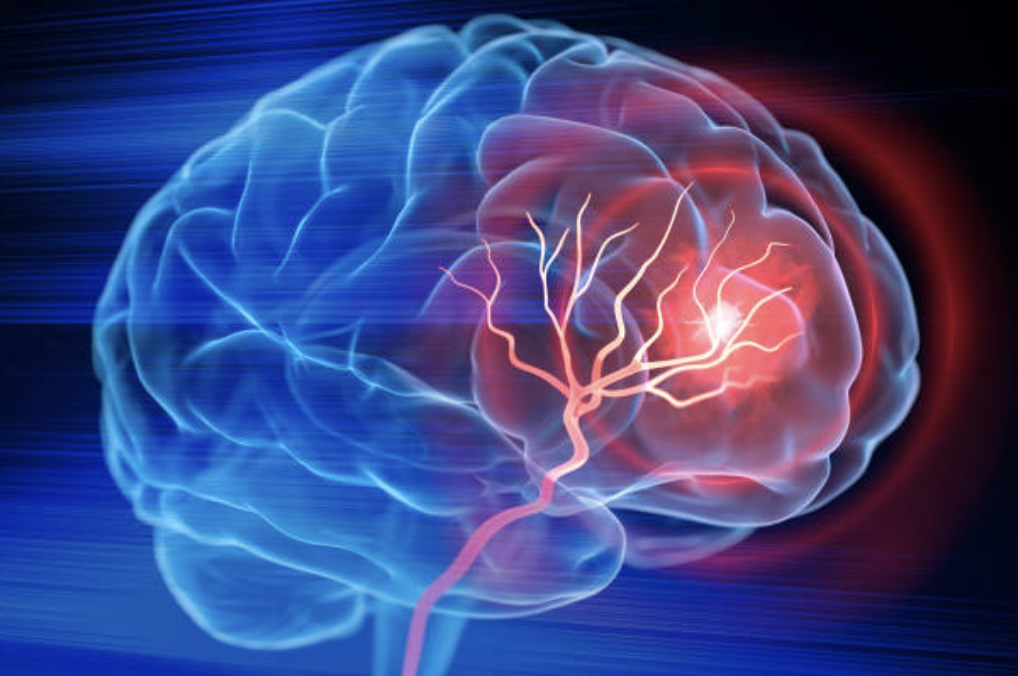

Stroke, also called a “brain attack,” occurs when blood flow to the brain is blocked or there is sudden bleeding in the brain(NIH 2023). This interruption can cause lasting brain damage, long-term disability, or even death. Stroke is a serious medical condition that requires emergency care, and it is one of the world’s leading causes of death and disability. Stroke analysis is an integral part of modern healthcare, as early recognition of symptoms can provide critical information for predicting strokes and promoting a healthy lifestyle(Dritsas and Trigka 2022).

Moreover, since strokes are both preventable and treatable(CDC Centers for Disease Control and Prevention 2023), individuals can significantly reduce their risk by modifying their daily habits. Simple changes like improving diet, increasing physical activity, and managing stress can have a huge impact on stroke prevention(American Stroke Association 2022).

By analyzing and visually presenting the characteristics of groups of stroke patients to others, even those without a medical background can gain a clear understanding of the risk factors associated with strokes. This approach not only helps in recognizing the lifestyle and environmental factors that contribute to strokes, but also allows individuals to identify and alter their behaviors that may increase the risk of stroke(Zheng, Chen, and Sawan 2022; “Risk Factors, Clinical Presentations, and Predictors of Stroke Among Adult Patients” 2022; “Using Machine Learning Models to Improve Stroke Risk Level Classification Methods” 2022; “Stroke Risk Prediction with Machine Learning Techniques” 2022). This awareness and intervention can substantially reduce the chances of suffering a stroke, enhancing both individual and public health.

## References

American Stroke Association. 2022. “Stroke Risk Factors.” https://www.stroke.org/en/about-stroke/stroke-risk-factors.

CDC Centers for Disease Control and Prevention. 2023. “About Stroke.” https://www.cdc.gov/stroke/index.htm.

Dritsas, E., and M. Trigka. 2022. “Stroke Risk Prediction with Machine Learning Techniques.” *Sensors (Basel, Switzerland)* 22 (13): 4670. https://doi.org/10.3390/s22134670.

NIH. 2023. “What Is a Stroke?” https://www.nhlbi.nih.gov/health/stroke.

“Risk Factors, Clinical Presentations, and Predictors of Stroke Among Adult Patients.” 2022. *BMC Neurology*. https://bmcneurol.biomedcentral.com/articles/10.1186/s12883-022-02560-5.

“Stroke Risk Prediction with Machine Learning Techniques.” 2022. *MDPI Sensors*. https://www.mdpi.com/1424-8220/22/13/4670.

“Using Machine Learning Models to Improve Stroke Risk Level Classification Methods.” 2022. *BMC Medical Informatics and Decision Making*. https://bmcmedinformdecismak.biomedcentral.com/articles/10.1186/s12911-022-01857-4.

Zheng, W., Y.-H. Chen, and M. Sawan. 2022. “Longitudinal Data to Enhance Dynamic Stroke Risk Prediction.” *Healthcare* 10 (11): 2134. https://www.mdpi.com/2227-9032/10/11/2134.